# Statistical Rethinking - Chapter 3

Lucy Liu

Questions from ‘Statistical Rethinking’ by Richard McElreath, Chapter 3.

# Easy

```r
# code to generate samples from the posterior distribution
p_grid <- seq( from=0 , to=1 , length.out=1000 )
prior <- rep( 1 , 1000 )
likelihood <- dbinom( 6 , size=9 , prob=p_grid )
posterior <- likelihood * prior
posterior <- posterior / sum(posterior)
set.seed(100)
samples <- sample( p_grid , prob=posterior , size=1e4 , replace=TRUE )

# load rethinking library
library(rethinking)
```

First visualise samples using a histogram:

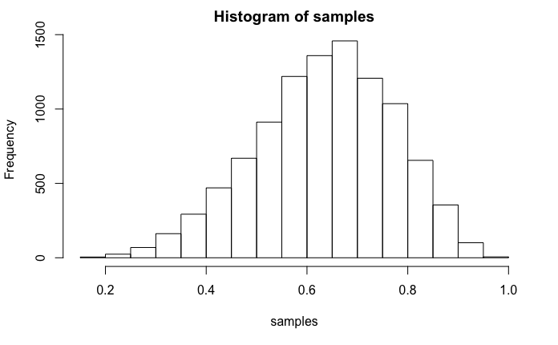

Questions:

1. Below 0.2

```r
sum(samples < 0.2)/ 1e4
```

```
[1] 5e-04
```

2. Above 0.8

```r
sum(samples > 0.8) / 1e4
```

```
[1] 0.1117
```

3. Between 0.2 & 0.8

```r
sum(samples > 0.2 & samples < 0.8) / 1e4
```

```
[1] 0.8878
```

4. Lowest 20%

```r
quantile(samples, 0.2)
```

```
      20%
0.5195195
```

5. Highest 20%

```r
quantile(samples, 0.8)
```

```
      80%
0.7567568
```

6. Narrowest 66%

```r
HPDI(samples, prob = 0.66)
```

```
    |0.66     0.66|
0.5205205 0.7847848
```

7. 66% PI

```r
PI(samples, prob = 0.66)
```

```
      17%       83%
0.5005005 0.7687688
```

# Medium

1. 8 water in 15 tosses

```r
p_grid <- seq( from=0 , to=1 , length.out=1000 )
prior <- rep( 1 , 1000 )
likelihood <- dbinom( 8 , size=15 , prob=p_grid )
posterior <- likelihood * prior
posterior <- posterior / sum(posterior)
```

2. Draw 10,000 samples. 90% HPDI

```r
HPDI(samples, prob = 0.9)
```

```
     |0.9      0.9|
0.3243243 0.7157157
```

3. Posterior predictive check.

```r
w <- rbinom(1e4, size = 15, prob = samples)
hist(w)
```

[output not shown]

Probability of observing 8 water:

```r
sum(w == 8)/1e4
```

[output not shown]

4. Using the posterior distribution from 8/15 data, calcualte probability of observing 6/9.

```r
sum(w == 6)/1e4
```

```
[1] 0.1766
```

5. New prior with 0 at p<0.5 and constant at p>0.5.

```r
p_grid <- seq( from=0 , to=1 , length.out=1000 )
prior <- ifelse(p_grid<0.5, 0 , 1)
```

- Construct posterior distribution using grid approximation

```r
likelihood <- dbinom( 8 , size=15 , prob=p_grid )
posterior <- likelihood * prior
posterior <- posterior / sum(posterior)
```

- Draw 1e4 samples. HPDI 90%. Note how the lowest p is 0.5 due to our new prior.

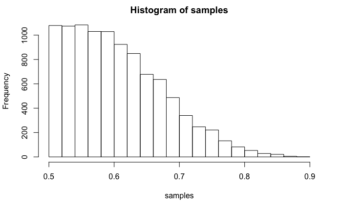

```r
HPDI(samples, prob = 0.9)
```

```
     |0.9      0.9|
0.5005005 0.7077077
```

- Construct posterior predictive check. What is probability of 8/15

```r
sum(w == 8) / 1e4
```

```
[1] 0.1617
```

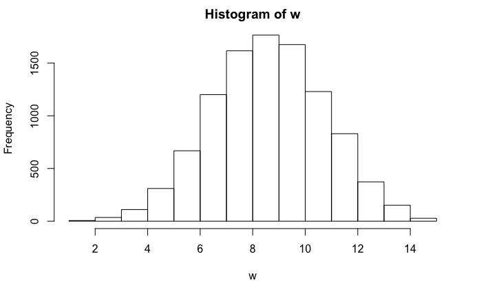

- Use posterior distribution to calculate probability of 6/9.

```r
sum(w == 6) / 1e4
```

```
[1] 0.2376
```

# Hard

Load data.

```r
data(homeworkch3)
# check data is correct
sum(birth1) + sum(birth2)
```

```
[1] 111
```

## Question 1

Computer posterior distribution. The probability of a birth being a boy ranges from 0-1. There are only 2 possible outcomes (boy or girl), which lends itself to a binomial distribution.

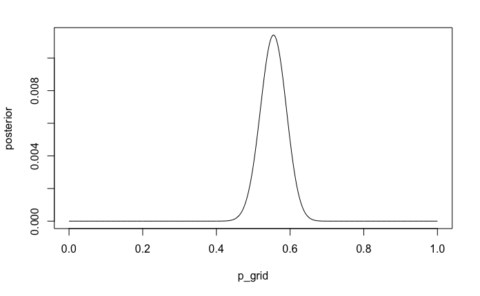

```r
p_grid[ which.max(posterior)]
```

```
[1] 0.5545546
```

## Question 2

Draw 1e4 samples from the posterior distribution.

```r
set.seed(100)
samples <- sample(p_grid , prob=posterior , size=1e4 , replace=TRUE )
```

```r
HPDI(samples, prob = 0.5)
```

```
     |0.5      0.5|
0.5315315 0.5765766
```

```r
HPDI(samples, prob = 0.89)
```

```
    |0.89     0.89|
0.4974975 0.6076076
```

## Question 3

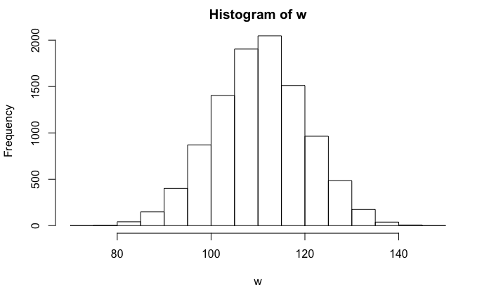

111 within the most likely bin in the histogram.

## Question 4

Unsure exactly what was meant by this question. I have simulate number of boys from 100 births using the samples from the posterior distribution.

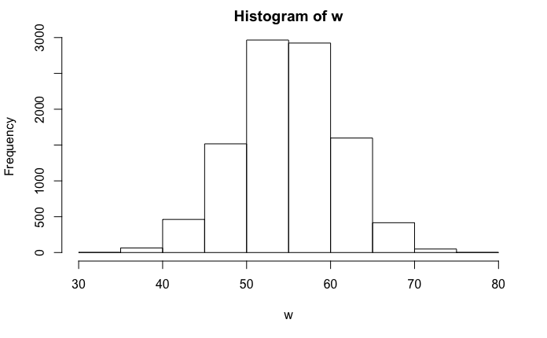

```r
sum(birth1)
```

```
[1] 51
```

51 is towards the edge of the histogram peak.

## Question 5

Count number of first borns who were girls.

```r
girl1
```

```
[1] 49
```

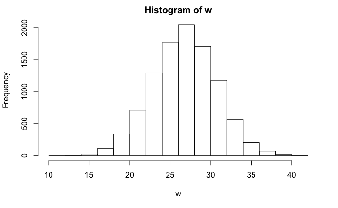

```r
w <- rbinom(1e4, size = 49, prob = samples)
hist(w)
```

Number of second born boys, when the first born was a girl.

```r
sum(birth2[birth1 == 0])
```

```
[1] 39
```

This is very much at the tail of the simulated distribution. It suggests that births are NOT independent (as you are more likely to get a second born boy when the first born is a girl, than the model predicts).

```r
sum(birth1)
```

```
[1] 51
```

```r
sum(birth2)
```

```
[1] 60
```

Boys appear to be more likely on the second birth?

```r
sum(birth2)
```

```
[1] 60
```

```r
sum(birth2[birth1 == 1])
```

```
[1] 21
```